# Introduction

In this study, it is aimed to figure out what kind of relationship exists between the variables to be processed and visualize the data to see their behaviour with respect to time. USD/TRY exchange rate, tourist numbers and average expenditure per capita, which are received from "EVDS", and search statistics of "Turkey" in travel category, which is received from "Google Trends", are used in this study. All data is monthly and they represents between 2011 and 2020.

To understand the time related relations line graphs, histograms and box plots are used for each of data. Moreover, to identify the relation between variables, correlation plot is used.

# Data Manipulation and Initialization

## Required Libraries

```r
library(readxl)
library(ggplot2)
library(dplyr)
library(tidyr)
library(lubridate)
library(RColorBrewer)
library(zoo)
library(ggcorrplot)
```

## Import the data

"EVDS.xlsx" file consists of SD/TRY exchange rate, tourist numbers and average expenditure per capita data. "multiTimeline.csv" file consists of "Turkey" search rates in travel category of Google Trends.

```r
#Read the data files
setwd("C:/Users/SaidBahçeci/Desktop/Assignment 1")
google_trends = read.csv("multiTimeline.csv")
evds_data = read_excel("EVDS.xlsx")
```

```r
#Combining data taken from EVDS and Google Trends
the_data = cbind(evds_data, google_trends[,2])
colnames(the_data) = c("Date","Tourist_Number","Avg_Spending","Dolar_Rate","Google_Trends")

#To adjust years to 2011-2018 last rows are subtracted
the_data = head(the_data, - 25)

#Date Manipulation
the_data$Date<-gsub("-","",as.character(the_data$Date))
the_data[,"Date"] = as.Date(as.yearmon(the_data[,"Date"],format = "%Y%m"), format = "%Y-%m-%d")

#Add "Year" column to use while drawing histograms
the_data$Year = factor(format(the_data$Date, "%Y"),
                     levels = c('2011', '2012', '2013', '2014', '2015', '2016', '2017', '2018'))

#Set NA values to zero
the_data[is.na(the_data[,"Avg_Spending"] )==T,"Avg_Spending"]=0
```

# Line Graphs, Histograms and Box Plots

## Visualization of USD/TRY Exchange Rate

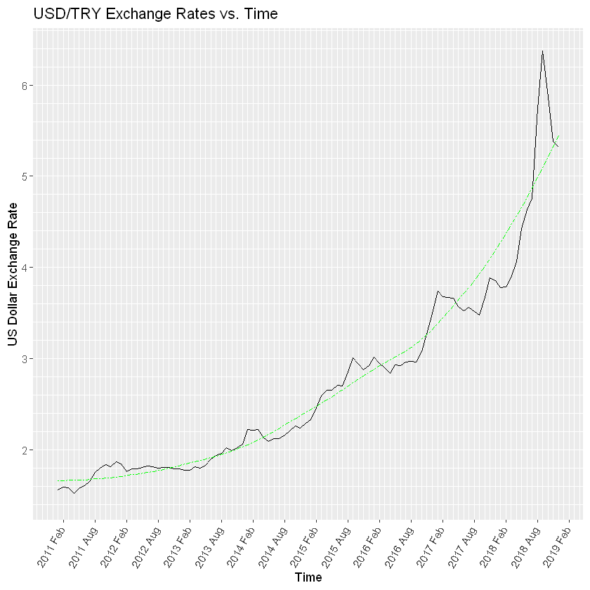

```r
#Plots the line graph of USD/TRy Exchange Rates
ggplot(data = the_data,aes(x = Date,y = Dolar_Rate)) + geom_line(color ="black") +
  geom_smooth(fill = NA, color="green",linetype = "twodash", size = 0.5) +
  labs(title = "USD/TRY Exchange Rates vs. Time",
       x = "Time",
       y = "US Dollar Exchange Rate" ) +
  scale_x_date(date_breaks = "6 month",
               date_labels = "%Y %b",
               date_minor_breaks = "1 month") +
  theme(axis.text.x=element_text(angle=60, hjust=1.4, vjust = 1.4)) +
  scale_y_continuous(breaks = seq(from = 0,to = 8,by = 1),
                     minor_breaks = seq(from = 0,to = 9,by = .2))
```

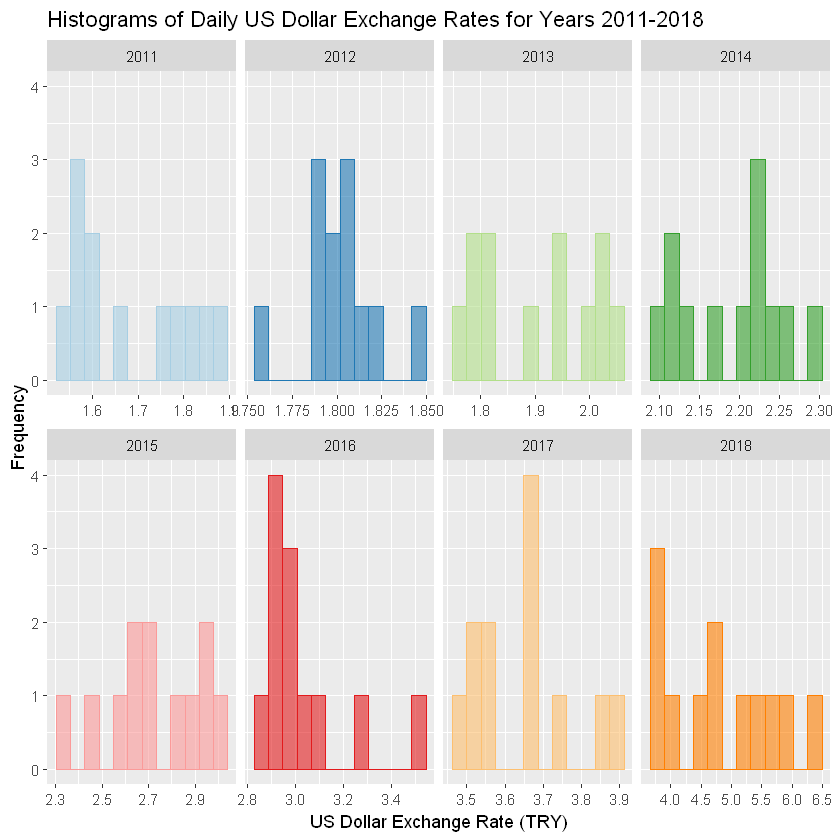

```r
#Plots the USD/TRY histograms
ggplot(data = the_data,aes(x = Dolar_Rate)) + geom_histogram(bins = 12, alpha = 0.6,aes(color = Year, fill = Year)) +
  facet_wrap(Year~.,scales = "free_x",ncol = 4) +
  scale_color_brewer(palette = "Paired") +
  scale_fill_brewer(palette = "Paired") +
  labs(title = "Histograms of Daily US Dollar Exchange Rates for Years 2011-2018",
       x = "US Dollar Exchange Rate (TRY)",
       y = "Frequency") +
  theme(legend.position = "none")
```

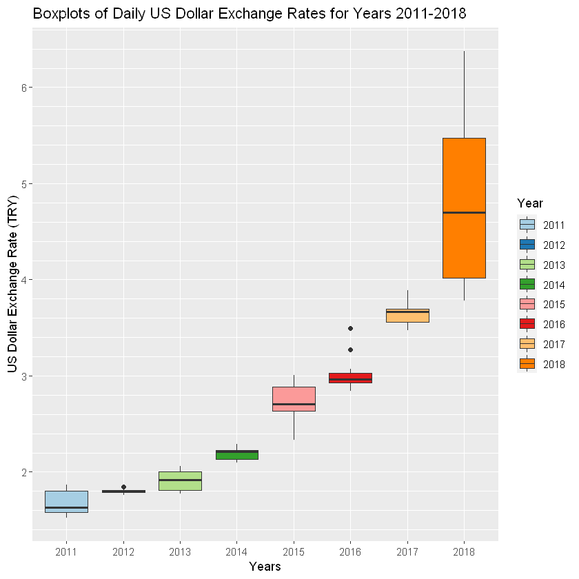

```r
#Plots the USD/TRY boxplots
ggplot(data = the_data,aes(x = Year,y = Dolar_Rate)) + geom_boxplot(aes(y = Dolar_Rate, fill=Year)) +
  scale_fill_brewer(palette="Paired") +
  labs(title = "Boxplots of Daily US Dollar Exchange Rates for Years 2011-2018",
       x = "Years",
       y = "US Dollar Exchange Rate (TRY)") +
  scale_y_continuous(breaks = seq(from = 0,to = 8,by = 1),
                     minor_breaks = seq(from = 0,to = 9,by = .2))
```

It is possible to mention that the USD/TRY parameter has exponential trend, it can be observed huge percentile increases starting from 2015. In addition to these, range of 2018's histogram is significantly higher than other years and there is an outstanding peak. It can be said that a rare event might have occured during that year.

## Visualization of Tourist Numbers

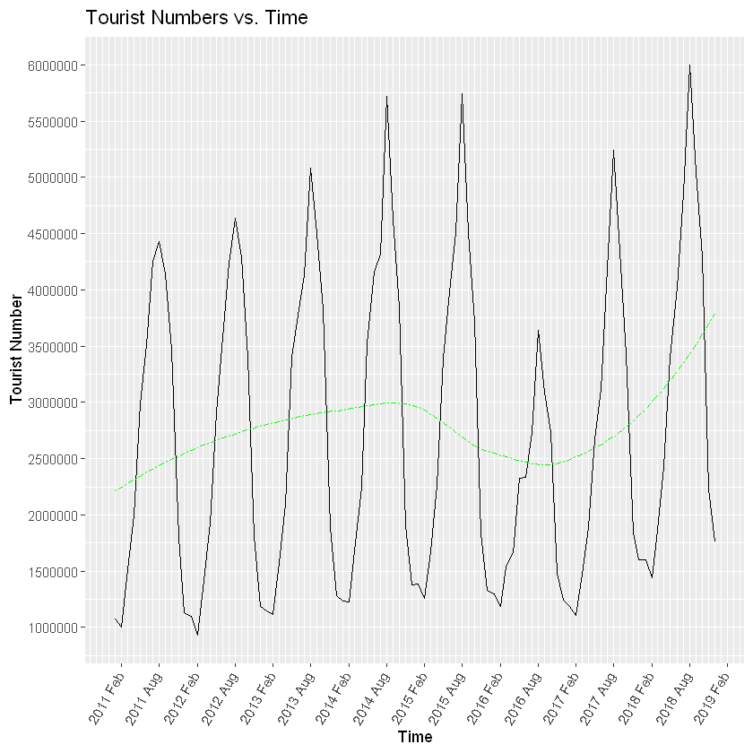

```r
#Plots the line graph of Tourist Numbers
ggplot(data = the_data,aes(x = Date,y = Tourist_Number)) + geom_line(color ="black") +
  geom_smooth(fill = NA, color="green",linetype = "twodash", size = 0.5) +
  labs(title = "Tourist Numbers vs. Time",
       x = "Time",
       y = "Tourist Number" ) +
  scale_x_date(date_breaks = "6 month",
               date_labels = "%Y %b",
               date_minor_breaks = "1 month") +
  theme(axis.text.x=element_text(angle=60, hjust=1.4, vjust = 1.4)) +
  scale_y_continuous(breaks = seq(from = 0,to = 10000000,by = 500000))
```

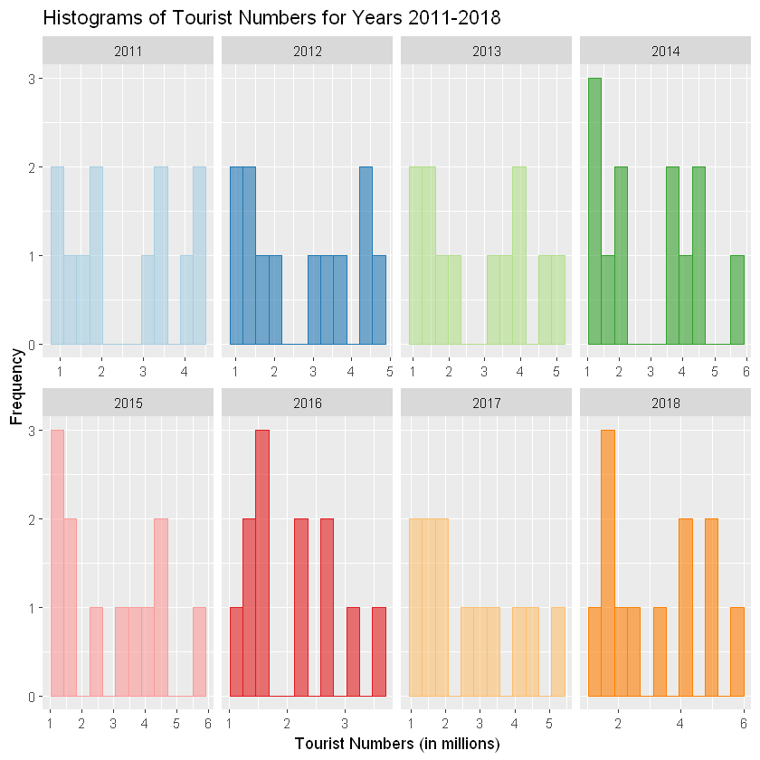

```r
#Plots the Tourist Numbers histograms
ggplot(data = the_data,aes(x = Tourist_Number/1000000)) + geom_histogram(bins = 12, alpha = 0.6,aes(color = Year, fill = Year)) +
  facet_wrap(Year~.,scales = "free_x",ncol = 4) +
  scale_color_brewer(palette = "Paired") +
  scale_fill_brewer(palette = "Paired") +
  labs(title = "Histograms of Tourist Numbers for Years 2011-2018",
       x = "Tourist Numbers (in millions)",
       y = "Frequency") +
  theme(legend.position = "none")
```

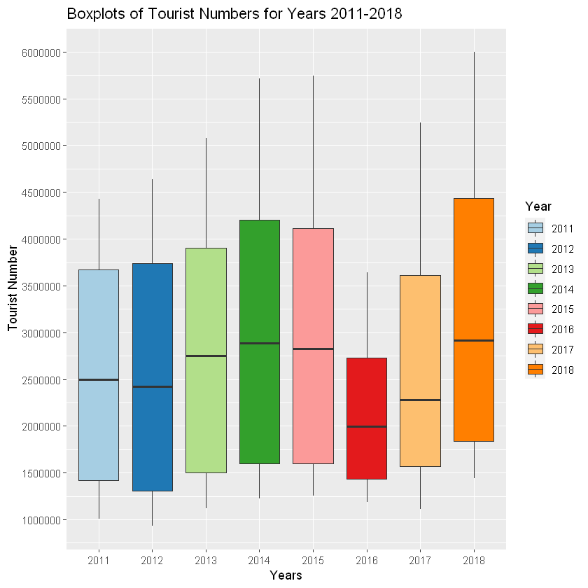

```r
#Plots the Tourist Number boxplots
ggplot(data = the_data,aes(x = Year,y = Tourist_Number)) + geom_boxplot(aes(y = Tourist_Number, fill=Year)) +
  scale_fill_brewer(palette="Paired") +
  labs(title = "Boxplots of Tourist Numbers for Years 2011-2018",
       x = "Years",
       y = "Tourist Number") +
  scale_y_continuous(breaks = seq(from = 0,to = 10000000,by = 500000))
```

By looking the line graph of tourist numbers, it can be easily said that there is an seasonality effect. In summer months, there is a huge increase in the numbers, whereas, in winter months, the numbers drop to significantly low levels. Moreover, while seeing on the rise trend until 2016, it is possible that an unusal event took place in 2016 which affects following year too. On the other hand, probably, the trend is still valid for year 2018.

## Visualization of Average Expenditure Per Capita

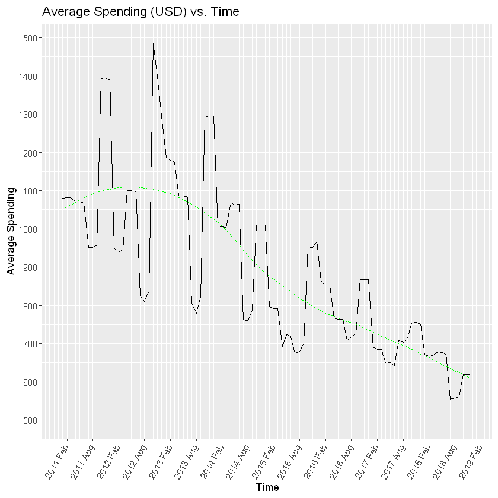

```r
#Plots the line graph of Average Spending per Capita
ggplot(data = the_data,aes(x = Date,y = Avg_Spending)) + geom_line(color ="black") +
  geom_smooth(fill = NA, color="green",linetype = "twodash", size = 0.5) +
  labs(title = "Average Spending (USD) vs. Time",
       x = "Time",
       y = "Average Spending" ) +
  scale_x_date(date_breaks = "6 month",
               date_labels = "%Y %b",
               date_minor_breaks = "1 month") +
  theme(axis.text.x=element_text(angle=60, hjust=1.4, vjust = 1.4)) +
  scale_y_continuous(breaks = seq(from = 0,to = 1500,by = 100))
```

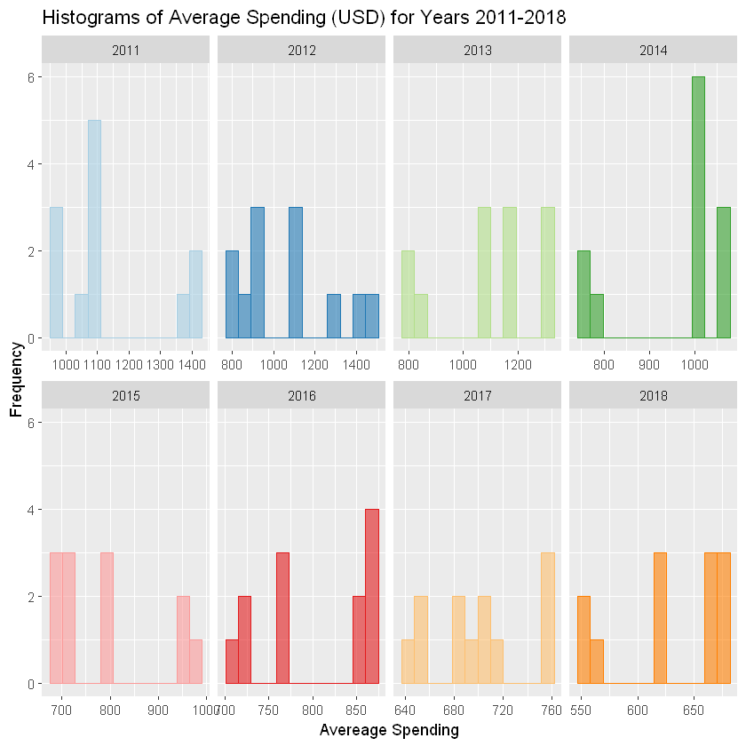

```r
#Plots the Average Spending per Tourist histograms
ggplot(data = the_data,aes(x = Avg_Spending)) + geom_histogram(bins = 12, alpha = 0.6,aes(color = Year, fill = Year)) +
  facet_wrap(Year~.,scales = "free_x",ncol = 4) +
  scale_color_brewer(palette = "Paired") +
  scale_fill_brewer(palette = "Paired") +
  labs(title = "Histograms of Average Spending (USD) for Years 2011-2018",
       x = "Avereage Spending",
       y = "Frequency") +
  theme(legend.position = "none")
```

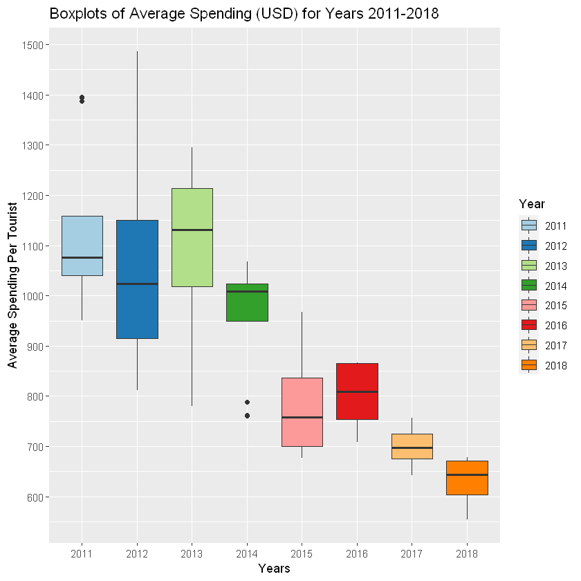

```r
#Plots the Tourist Number boxplots
ggplot(data = the_data,aes(x = Year,y = Avg_Spending)) + geom_boxplot(aes(y = Avg_Spending, fill=Year)) +
  scale_fill_brewer(palette="Paired") +
  labs(title = "Boxplots of Average Spending (USD) for Years 2011-2018",
       x = "Years",
       y = "Average Spending Per Tourist") +
  scale_y_continuous(breaks = seq(from = 0,to = 1500,by = 100))
```

By looking the line graph of average spending per capita, it can be said that the lowest levels of years are prone to be seen in August and recent months, whereas the highest levels are seen around fall months. Also, the trend is downward which probably affected from USD/TRY rate. Since the USD rate is constantly raising, their expenditures are tend to get lower in terms of USD.

## Visualization of Search Rate of "Turkey" in Travel Category

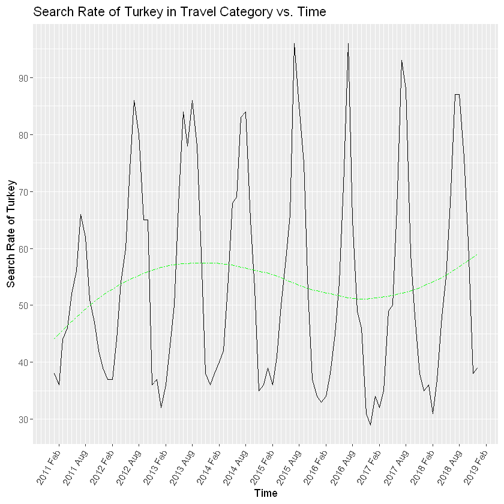

```r
#Plots the line graph of search rate of "Turkey" in travel category of Google Trends
ggplot(data = the_data,aes(x = Date,y = Google_Trends)) + geom_line(color ="black") +
  geom_smooth(fill = NA, color="green",linetype = "twodash", size = 0.5) +
  labs(title = "Search Rate of Turkey in Travel Category vs. Time",
       x = "Time",
       y = "Search Rate of Turkey" ) +
  scale_x_date(date_breaks = "6 month",
               date_labels = "%Y %b",
               date_minor_breaks = "1 month") +
  theme(axis.text.x=element_text(angle=60, hjust=1.4, vjust = 1.4)) +
  scale_y_continuous(breaks = seq(from = 0,to = 100,by = 10))
```

[figure not shown]

```r
#Plots the search rate of "Turkey" in travel category of Google Trends histograms
ggplot(data = the_data,aes(x = Google_Trends)) + geom_histogram(bins = 12, alpha = 0.6,aes(color = Year, fill = Year)) +
  facet_wrap(Year~.,scales = "free_x",ncol = 4) +
  scale_color_brewer(palette = "Paired") +
  scale_fill_brewer(palette = "Paired") +
  labs(title = "Histograms of Search Rate of Turkey in Travel Category for Years 2011-2018",
       x = "Search Rate of Turkey",
       y = "Frequency") +
  theme(legend.position = "none")
```

[figure not shown]

```r
#Plots the search rate of "Turkey" in travel category of Google Trends boxplots
ggplot(data = the_data,aes(x = Year,y = Google_Trends)) + geom_boxplot(aes(y = Google_Trends, fill=Year)) +
  scale_fill_brewer(palette="Paired") +
  labs(title = "Boxplots of Search Rate of Turkey in Travel Category for Years 2011-2018",
       x = "Years",
       y = "Search Rate of Turkey") +
  scale_y_continuous(breaks = seq(from = 0,to = 100,by = 10))
```

By looking at the line graph, it can be said that there is a strong seasonailty which raises the search rates in summer months while decreases the search rates in winter months. It is not concluded that there is an obvious trend which gives and idea about the data. On the other hand, it is seen that there is a decreasing in the search rates in 2016 and constant increase in upcoming years. From this point, the data has significant similarity between tourist numbers.

# Data Manipulation for Correlation

Since there is a strong seasonalilty in tourist numbers' graph, it is meaningful to take their smoothed values instead of their actual values.

```r
#Add smoothed tourist numbers as column to see a meaningful relationship between dolar rate and tourist numbers.
#By this way, we can avoid the effect of seasonality.
lowess_values = lowess(the_data$Tourist_Number)
names(lowess_values)[2] ="Smoothed Tourist Number"
the_data = cbind(the_data, lowess_values[2])
the_data
```

| Date | Tourist_Number | Avg_Spending | Dolar_Rate | Google_Trends | Year | Smoothed Tourist Number |
| --- | --- | --- | --- | --- | --- | --- |
| 2011-01-01 | 1079135 | 1080 | 1.561310 | 38 | 2011 | 2347465 |
| 2011-02-01 | 1004108 | 1082 | 1.590470 | 36 | 2011 | 2363100 |
| 2011-03-01 | 1515953 | 1082 | 1.582265 | 44 | 2011 | 2378597 |
| 2011-04-01 | 2002607 | 1071 | 1.522938 | 46 | 2011 | 2393986 |
| 2011-05-01 | 2988727 | 1070 | 1.571705 | 52 | 2011 | 2409308 |
| 2011-06-01 | 3512503 | 1068 | 1.601700 | 56 | 2011 | 2424610 |
| 2011-07-01 | 4250199 | 951 | 1.654657 | 66 | 2011 | 2439934 |
| 2011-08-01 | 4427495 | 951 | 1.752648 | 62 | 2011 | 2455311 |
| 2011-09-01 | 4142092 | 957 | 1.795143 | 51 | 2011 | 2470752 |
| 2011-10-01 | 3464540 | 1394 | 1.835895 | 47 | 2011 | 2486253 |
| 2011-11-01 | 1802660 | 1395 | 1.812463 | 42 | 2011 | 2501788 |
| 2011-12-01 | 1134509 | 1388 | 1.867823 | 39 | 2011 | 2517320 |
| 2012-01-01 | 1097254 | 950 | 1.847814 | 37 | 2012 | 2532814 |
| 2012-02-01 | 932503 | 941 | 1.759533 | 37 | 2012 | 2548243 |
| 2012-03-01 | 1344975 | 945 | 1.787882 | 44 | 2012 | 2563590 |
| 2012-04-01 | 1930140 | 1101 | 1.788420 | 54 | 2012 | 2578851 |
| 2012-05-01 | 2907105 | 1100 | 1.805627 | 60 | 2012 | 2594032 |
| 2012-06-01 | 3575063 | 1097 | 1.824833 | 74 | 2012 | 2609146 |
| 2012-07-01 | 4240079 | 825 | 1.813591 | 86 | 2012 | 2624201 |
| 2012-08-01 | 4636889 | 811 | 1.794440 | 80 | 2012 | 2639200 |
| 2012-09-01 | 4284149 | 838 | 1.804275 | 65 | 2012 | 2654125 |
| 2012-10-01 | 3397483 | 1487 | 1.802780 | 65 | 2012 | 2668934 |
| 2012-11-01 | 1807663 | 1399 | 1.794050 | 36 | 2012 | 2683553 |
| 2012-12-01 | 1189161 | 1296 | 1.787676 | 37 | 2012 | 2697886 |
| 2013-01-01 | 1147136 | 1187 | 1.772368 | 32 | 2013 | 2711814 |
| 2013-02-01 | 1117425 | 1179 | 1.776035 | 36 | 2013 | 2725211 |
| 2013-03-01 | 1577358 | 1175 | 1.810457 | 43 | 2013 | 2737935 |
| 2013-04-01 | 2096105 | 1086 | 1.799690 | 50 | 2013 | 2749830 |
| 2013-05-01 | 3402790 | 1087 | 1.826050 | 70 | 2013 | 2760719 |
| 2013-06-01 | 3773896 | 1083 | 1.897915 | 84 | 2013 | 2770418 |
| ... | ... | ... | ... | ... | ... | ... |
| 2016-07-01 | 2733909 | 708 | 2.962878 | 96 | 2016 | 2608143 |
| 2016-08-01 | 3642977 | 717 | 2.968200 | 65 | 2016 | 2624180 |
| 2016-09-01 | 3089623 | 726 | 2.965422 | 49 | 2016 | 2640589 |
| 2016-10-01 | 2730649 | 867 | 3.073490 | 46 | 2016 | 2657017 |
| 2016-11-01 | 1479030 | 867 | 3.273323 | 31 | 2016 | 2673345 |
| 2016-12-01 | 1244101 | 867 | 3.495223 | 29 | 2016 | 2689563 |
| 2017-01-01 | 1184957 | 691 | 3.741614 | 34 | 2017 | 2705715 |
| 2017-02-01 | 1110950 | 685 | 3.678985 | 32 | 2017 | 2721875 |
| 2017-03-01 | 1476386 | 684 | 3.672548 | 35 | 2017 | 2738124 |
| 2017-04-01 | 1889519 | 649 | 3.660400 | 49 | 2017 | 2754550 |
| 2017-05-01 | 2670106 | 650 | 3.570271 | 50 | 2017 | 2771239 |
| 2017-06-01 | 3115407 | 642 | 3.525340 | 67 | 2017 | 2788268 |
| 2017-07-01 | 4188105 | 708 | 3.566281 | 93 | 2017 | 2805704 |
| 2017-08-01 | 5242858 | 704 | 3.518800 | 88 | 2017 | 2823595 |
| 2017-09-01 | 4339345 | 716 | 3.474295 | 59 | 2017 | 2841972 |
| 2017-10-01 | 3421449 | 754 | 3.668873 | 48 | 2017 | 2860841 |
| 2017-11-01 | 1836496 | 756 | 3.886036 | 38 | 2017 | 2880194 |
| 2017-12-01 | 1603949 | 752 | 3.854624 | 35 | 2017 | 2900021 |
| 2018-01-01 | 1601862 | 670 | 3.779123 | 36 | 2018 | 2920316 |
| 2018-02-01 | 1444008 | 668 | 3.784830 | 31 | 2018 | 2941087 |
| 2018-03-01 | 1862961 | 669 | 3.887855 | 37 | 2018 | 2962353 |
| 2018-04-01 | 2433008 | 678 | 4.061345 | 48 | 2018 | 2984144 |
| 2018-05-01 | 3398215 | 677 | 4.422082 | 55 | 2018 | 3006497 |
| 2018-06-01 | 4023879 | 672 | 4.636550 | 68 | 2018 | 3029450 |
| 2018-07-01 | 4857186 | 554 | 4.756555 | 87 | 2018 | 3053036 |
| 2018-08-01 | 6001678 | 557 | 5.740522 | 87 | 2018 | 3077272 |
| 2018-09-01 | 5045870 | 560 | 6.378340 | 76 | 2018 | 3102158 |
| 2018-10-01 | 4292466 | 620 | 5.869927 | 61 | 2018 | 3127665 |
| 2018-11-01 | 2234062 | 619 | 5.383173 | 38 | 2018 | 3153748 |
| 2018-12-01 | 1756707 | 618 | 5.315690 | 39 | 2018 | 3180351 |

# Correlation

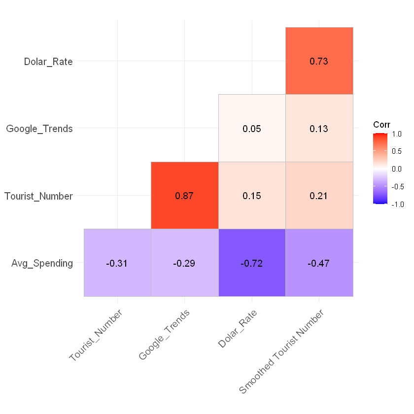

```r
#Correlation
correl_info = cor(the_data[c(2,3,4,5,7)])
ggcorrplot(correl_info,
           hc.order = TRUE,
           type = "lower",
           lab = TRUE)
```

First thing that is conspicuous is, there is strong corelation between search rates of "Turkey" and tourist numbers which is reasonable, since they have similar seasonality. In addition, there is a strong negative correlation between dolar rate and average spending. As mentioned before, this is a result of that value of Turkish Liras is exponentially decreasing against USD. They can purchase same amount of services or products, while spending less amount of money in terms of USD. And, again as a result of USD rates changing, as expected, there is respectively strong correlation between dolar rate and smoothed tourist numbers. This change in USD rates, made Turkey more attractive and inexpensive choice for tourists.

# Conclusion

To sum up, I chose three different monthly data from EVDS which are Tourist Numbers, USD/TRY Exchange Rate and, Average Expenditure per Capita, and chose a data about "Turkey" search rates in travel category from Google Trends. The aim while choosing these data was to see if there is a seasonality, trends and existence of the possible relationship between those. It is turned out that Tourist Numbers and "Turkey" Search Rates and, Average Expenditure per Capita have seasonality. USD/TRY exchange probably has exponential upward trend. On the other hand, while dolar rate has strong negative correlation between average expenditure and positive correlation between smoothed tourist numbers, search statistics of "Turkey" has strong relation between tourist numbers.